# Prevention Advisory For Severe Weather Events in U.S.

Jacky Pan

# Synopsis

Storms and other severe weather events can cause both public health and economic problems for communities and municipalities in U.S. Many severe events can result in fatalities, injuries, and property damage, and preventing such outcomes to the extent possible is a key concern.

For prevention, we explore the U.S. National Oceanic and Atmospheric Administration’s (NOAA) storm database. This database tracks characteristics of major storms and weather events in the United States, including when and where they occur, as well as estimates of any fatalities, injuries, and property damage.

> The results of analysis indicate that, from 1950 to Nov 2011:  
> 1. **Tornado** was the most harmful with respect to population health.  
> 2. **Flood** affected the greatest economic consequence(damage).

# Data Processing

### Data Preparing

Downlaod the storm datasets for this project.

```r
if(!file.exists("repdata-data-StormData.csv.bz2")){
        url <- "https://d396qusza40orc.cloudfront.net/repdata%2Fdata%2FStormData.csv.bz2"
        download.file(url, destfile = "repdata-data-StormData.csv.bz2", method = "curl")
}
```

Load the data.  
Note: `stringAsFactors = FALSE` is for future data cleaning.

```r
data <- read.csv(bzfile("repdata-data-StormData.csv.bz2"), header = TRUE, stringsAsFactors = FALSE)
```

### Data Exploration

There are 902297 records in our datasets with 37 different variables

```r
dim(data)
```

```
## [1] 902297     37
```

The variables in columns are the following:

```r
names(data)
```

```
##  [1] "STATE__"    "BGN_DATE"   "BGN_TIME"   "TIME_ZONE"  "COUNTY"
##  [6] "COUNTYNAME" "STATE"      "EVTYPE"     "BGN_RANGE"  "BGN_AZI"
## [11] "BGN_LOCATI" "END_DATE"   "END_TIME"   "COUNTY_END" "COUNTYENDN"
## [16] "END_RANGE"  "END_AZI"    "END_LOCATI" "LENGTH"     "WIDTH"
## [21] "F"          "MAG"        "FATALITIES" "INJURIES"   "PROPDMG"
## [26] "PROPDMGEXP" "CROPDMG"    "CROPDMGEXP" "WFO"        "STATEOFFIC"
## [31] "ZONENAMES"  "LATITUDE"   "LONGITUDE"  "LATITUDE_E" "LONGITUDE_"
## [36] "REMARKS"    "REFNUM"
```

Here is the brief overview of this datasets

```r
head(data)
```

```
##   STATE__           BGN_DATE BGN_TIME TIME_ZONE COUNTY COUNTYNAME STATE
## 1       1  4/18/1950 0:00:00     0130       CST     97     MOBILE    AL
## 2       1  4/18/1950 0:00:00     0145       CST      3    BALDWIN    AL
## 3       1  2/20/1951 0:00:00     1600       CST     57    FAYETTE    AL
## 4       1   6/8/1951 0:00:00     0900       CST     89    MADISON    AL
## 5       1 11/15/1951 0:00:00     1500       CST     43    CULLMAN    AL
## 6       1 11/15/1951 0:00:00     2000       CST     77 LAUDERDALE    AL
##    EVTYPE BGN_RANGE BGN_AZI BGN_LOCATI END_DATE END_TIME COUNTY_END
## 1 TORNADO         0                                               0
## 2 TORNADO         0                                               0
## 3 TORNADO         0                                               0
## 4 TORNADO         0                                               0
## 5 TORNADO         0                                               0
## 6 TORNADO         0                                               0
##   COUNTYENDN END_RANGE END_AZI END_LOCATI LENGTH WIDTH F MAG FATALITIES
```

[output cut: 20 more lines]

```r
summary(data)
```

```
##     STATE__       BGN_DATE           BGN_TIME          TIME_ZONE
##  Min.   : 1.0   Length:902297      Length:902297      Length:902297
##  1st Qu.:19.0   Class :character   Class :character   Class :character
##  Median :30.0   Mode  :character   Mode  :character   Mode  :character
##  Mean   :31.2
##  3rd Qu.:45.0
##  Max.   :95.0
##
##      COUNTY       COUNTYNAME           STATE              EVTYPE
##  Min.   :  0.0   Length:902297      Length:902297      Length:902297
##  1st Qu.: 31.0   Class :character   Class :character   Class :character
##  Median : 75.0   Mode  :character   Mode  :character   Mode  :character
##  Mean   :100.6
##  3rd Qu.:131.0
##  Max.   :873.0
##
##    BGN_RANGE          BGN_AZI           BGN_LOCATI
##  Min.   :   0.000   Length:902297      Length:902297
##  1st Qu.:   0.000   Class :character   Class :character
##  Median :   0.000   Mode  :character   Mode  :character
##  Mean   :   1.484
##  3rd Qu.:   1.000
##  Max.   :3749.000
##
##    END_DATE           END_TIME           COUNTY_END COUNTYENDN
##  Length:902297      Length:902297      Min.   :0    Mode:logical
##  Class :character   Class :character   1st Qu.:0    NA's:902297
##  Mode  :character   Mode  :character   Median :0
##                                        Mean   :0
##                                        3rd Qu.:0
##                                        Max.   :0
##
##    END_RANGE          END_AZI           END_LOCATI
##  Min.   :  0.0000   Length:902297      Length:902297
##  1st Qu.:  0.0000   Class :character   Class :character
##  Median :  0.0000   Mode  :character   Mode  :character
##  Mean   :  0.9862
##  3rd Qu.:  0.0000
##  Max.   :925.0000
##
```

[output cut: 33 more lines]

```
##  Min.   :-14451   Min.   :   0   Min.   :-14455   Length:902297
##  1st Qu.:  7247   1st Qu.:   0   1st Qu.:     0   Class :character
##  Median :  8707   Median :   0   Median :     0   Mode  :character
##  Mean   :  6940   Mean   :1452   Mean   :  3509
##  3rd Qu.:  9605   3rd Qu.:3549   3rd Qu.:  8735
##  Max.   : 17124   Max.   :9706   Max.   :106220
##                   NA's   :40
##      REFNUM
##  Min.   :     1
##  1st Qu.:225575
##  Median :451149
##  Mean   :451149
##  3rd Qu.:676723
##  Max.   :902297
##
```

After the exploration, we only need the variables regarding population health and economic consequence related to the severe weather events. The choosing variable `REMARKS` is to understand the details of each weather event record.

```r
data_for_analysis <- data[,c("EVTYPE", "FATALITIES", "INJURIES", "PROPDMG", "PROPDMGEXP", "CROPDMG", "CROPDMGEXP","REMARKS")]
```

We reorder the event type variable `EVTYPE` for future convenience of data cleaning.

```r
data_for_analysis <- data_for_analysis[order(data_for_analysis[,"EVTYPE"]),]
```

**Uppercase** the `EVTYPE` for convenience of data cleaning also.

```r
data_for_analysis$EVTYPE <- toupper(data_for_analysis$EVTYPE)
```

### Data Transformation

In this part, we want to derive the total amount of economic damage each weather event caused. Reformating the `PROPDMG` and `CROPDMG` by `PROPDMGEXP` and `CROPDMGEXP` respectively is the goal of data transformation.

We use `dplyr` package to better execute transformation.

```r
library(dplyr)
```

Referecing from [this online source](https://rstudio-pubs-static.s3.amazonaws.com/58957_37b6723ee52b455990e149edde45e5b6.html), we can know the symbol meaning of `PROPDMGEXP`.

```r
unique(data_for_analysis$PROPDMGEXP)
```

```
##  [1] "K" ""  "M" "+" "0" "5" "4" "7" "?" "B" "1" "2" "m" "8" "H" "-" "3"
## [18] "h" "6"
```

Replace the symbols into numberic representation.

```r
data_for_analysis[data_for_analysis$PROPDMGEXP == "+",]$PROPDMGEXP <- 1
data_for_analysis[data_for_analysis$PROPDMGEXP == "-",]$PROPDMGEXP <- 0
data_for_analysis[data_for_analysis$PROPDMGEXP == "?",]$PROPDMGEXP <- 0
data_for_analysis[data_for_analysis$PROPDMGEXP == "B",]$PROPDMGEXP <- 9
data_for_analysis[data_for_analysis$PROPDMGEXP%in%c("H","h"),]$PROPDMGEXP <- 2
data_for_analysis[data_for_analysis$PROPDMGEXP%in%c("K","k"),]$PROPDMGEXP <- 3
data_for_analysis[data_for_analysis$PROPDMGEXP%in%c("M","m"),]$PROPDMGEXP <- 6
data_for_analysis[data_for_analysis$PROPDMGEXP %in% c("0","1","2","3","4","5","6","7","8"),]$PROPDMGEXP <- 1
data_for_analysis[data_for_analysis$PROPDMGEXP == "",]$PROPDMGEXP <- 0
```

Like previous one, we can know the symbol meaning of `CROPDMGEXP` also.

```r
unique(data_for_analysis$CROPDMGEXP)
```

```
## [1] ""  "M" "K" "B" "0" "?" "k" "m" "2"
```

Replace the symbols into numberic representation again.

```r
data_for_analysis[data_for_analysis$CROPDMGEXP == "?",]$CROPDMGEXP <- 0
data_for_analysis[data_for_analysis$CROPDMGEXP == "B",]$CROPDMGEXP <- 9
data_for_analysis[data_for_analysis$CROPDMGEXP%in%c("K","k"),]$CROPDMGEXP <- 3
data_for_analysis[data_for_analysis$CROPDMGEXP%in%c("M","m"),]$CROPDMGEXP <- 6
data_for_analysis[data_for_analysis$CROPDMGEXP %in% c("0","1","2","3","4","5","6","7","8"),]$CROPDMGEXP <- 1
data_for_analysis[data_for_analysis$CROPDMGEXP == "",]$CROPDMGEXP <- 0
```

Make sure each numeric representation is in `numeric` data type.

```r
data_for_analysis$PROPDMGEXP <- as.numeric(data_for_analysis$PROPDMGEXP)
data_for_analysis$CROPDMGEXP <- as.numeric(data_for_analysis$CROPDMGEXP)
```

Finally, create the new variables `PROPDMG_NEW` and `CROPDMG_NEW` for future usage.

```r
data_for_analysis<-mutate(data_for_analysis, PROPDMG_NEW = PROPDMG * 10^PROPDMGEXP)
data_for_analysis<-mutate(data_for_analysis, CROPDMG_NEW = CROPDMG * 10^CROPDMGEXP)
```

### Data Cleaning: EVTYPE

There are lots of duplicated, mispelled and irrelevant items in `EVTYPE` column. Based on the previous exploration, We rename or delete the original items to meet the permitted weather event naming requirement.

```r
data_for_analysis <- data_for_analysis[!grepl("SUMMARY", data_for_analysis$EVTYPE),]
data_for_analysis[grepl("DUST DEVIL|DUST DEVEL", data_for_analysis$EVTYPE),]$EVTYPE <- "DUST DEVIL"
data_for_analysis[grepl("^WATERSPOUT| WATERSPOUT|WAYTERSPOUT|WATER SPOUT", data_for_analysis$EVTYPE),]$EVTYPE <- "WATERSPOUT"
data_for_analysis[grepl("TORNADO|LANDSPOUT|TORNDAO|WHIRLWIND|WALL CLOUD|GUSTNADO", data_for_analysis$EVTYPE),]$EVTYPE <- "TORNADO"
data_for_analysis[data_for_analysis$EVTYPE == "MARINE MISHAP",]$EVTYPE <- "MARINE HIGH WIND"
data_for_analysis[data_for_analysis$EVTYPE == "MARINE TSTM WIND",]$EVTYPE <- "MARINE THUNDERSTORM WIND"
data_for_analysis[data_for_analysis$EVTYPE == "NON TSTM WIND",]$EVTYPE <- "TROPICAL STORM"
data_for_analysis[data_for_analysis$EVTYPE == "NON-TSTM WIND",]$EVTYPE <- "TROPICAL STORM"
data_for_analysis[grepl("TROPICAL STORM", data_for_analysis$EVTYPE),]$EVTYPE <- "TROPICAL STORM"
data_for_analysis[grepl("^HIGH WIND", data_for_analysis$EVTYPE),]$EVTYPE <- "HIGH WIND"
data_for_analysis[grepl("(HURRICANE|TYPHOON)|REMNANTS OF FLOYD", data_for_analysis$EVTYPE),]$EVTYPE <- "HURRICANE(TYPHOON)"
data_for_analysis[grepl("^BLIZZARD", data_for_analysis$EVTYPE),]$EVTYPE <- "BLIZZARD"
data_for_analysis[data_for_analysis$EVTYPE == "GROUND BLIZZARD",]$EVTYPE <- "BLIZZARD"
data_for_analysis[grepl("FIRE", data_for_analysis$EVTYPE),]$EVTYPE <- "WILDFIRE"
data_for_analysis[grepl("COASTAL FLOOD|COASTALFLOOD|COASTAL/TIDAL FLOOD|CSTL|COASTAL  FLOODING|TIDAL FLOOD", data_for_analysis$EVTYPE),]$EVTYPE <- "COASTAL FLOOD"
data_for_analysis[grepl("^AVA", data_for_analysis$EVTYPE),]$EVTYPE <- "AVALANCHE"
data_for_analysis[grepl("RIP", data_for_analysis$EVTYPE),]$EVTYPE <- "RIP CURRENT"
data_for_analysis[grepl("HEAVY SNOW", data_for_analysis$EVTYPE),]$EVTYPE <- "HEAVY SNOW"
data_for_analysis[grepl("(SLEET|FREEZING RAIN)", data_for_analysis$EVTYPE),]$EVTYPE <- "SLEET"
data_for_analysis[grepl("DENSE FOG", data_for_analysis$EVTYPE),]$EVTYPE <- "DENSE FOG"
data_for_analysis[grepl("LAND|(ROCK SLIDE)|MUDSLIDE|MUD SLIDE", data_for_analysis$EVTYPE),]$EVTYPE <- "DEBRIS FLOW"
data_for_analysis[grepl("LAKE FLOOD", data_for_analysis$EVTYPE),]$EVTYPE <- "LAKESHORE FLOOD"
data_for_analysis[grepl("LAKE EFFECT SNOW|HEAVY LAKE SNOW", data_for_analysis$EVTYPE),]$EVTYPE <- "LAKE-EFFECT SNOW"
data_for_analysis[grepl("VOLCANIC", data_for_analysis$EVTYPE),]$EVTYPE <- "VOLCANIC ASH"
data_for_analysis[grepl("FROST|FREEZE|GLAZE", data_for_analysis$EVTYPE),]$EVTYPE <- "FROST/FREEZE"
data_for_analysis[grepl("Dense|dense",data_for_analysis$REMARKS) & data_for_analysis$EVTYPE == "FOG",]$EVTYPE <- "DENSE FOG"
data_for_analysis[grepl("Freezing|Icy|Ice|Cold",data_for_analysis$REMARKS, ignore.case = TRUE) & data_for_analysis$EVTYPE == "FOG",]$EVTYPE <- "FREEZING FOG"
data_for_analysis[grepl("^FOG", data_for_analysis$EVTYPE),]$EVTYPE <- "DENSE FOG"
data_for_analysis[grepl("ICE FOG", data_for_analysis$EVTYPE),]$EVTYPE <- "FREEZING FOG"
data_for_analysis[grepl("TSTM", data_for_analysis$EVTYPE),]$EVTYPE <- "THUNDERSTORM WIND"
data_for_analysis[grepl("^FLOOD", data_for_analysis$EVTYPE),]$EVTYPE <- "FLOOD"
data_for_analysis[grepl("ICE STORM|ICESTORM", data_for_analysis$EVTYPE),]$EVTYPE <- "ICE STORM"
data_for_analysis[grepl("THUNDERSTORM|THUNDERESTORM|TUNDERSTORM|THUNDEERSTORM|THUNDESTORM|THUDERSTORM|THUNERSTORM|METRO STORM, MAY 26|DOWNBURST", data_for_analysis$EVTYPE) & data_for_analysis$EVTYPE != "MARINE THUNDERSTORM WIND",]$EVTYPE <- "THUNDERSTORM WIND"
data_for_analysis[grepl("FLASH", data_for_analysis$EVTYPE),]$EVTYPE <- "FLASH FLOOD"
data_for_analysis[grepl("^LIGHTNING| LIGHTNING|LIGHTING", data_for_analysis$EVTYPE),]$EVTYPE <- "LIGHTNING"
data_for_analysis[grepl("HEAVY RAIN|RAINSTORM|RAIN (HEAVY)|EXCESSIVE RAINFALL|EXCESSIVE RAIN|RAIN", data_for_analysis$EVTYPE),]$EVTYPE <- "HEAVY RAIN"
data_for_analysis[grepl("HIGH SURF|HIGH SEAS", data_for_analysis$EVTYPE),]$EVTYPE <- "HIGH SURF"
data_for_analysis[grepl("(^EXCESSIVE HEAT)|(^EXTREME HEAT)|RECORD/EXCESSIVE HEAT|EXCESSIVE", data_for_analysis$EVTYPE),]$EVTYPE <- "EXCESSIVE HEAT"
data_for_analysis[grepl("DROUGHT|DRYNESS|DRY CONDITIONS", data_for_analysis$EVTYPE),]$EVTYPE <- "DROUGHT"
data_for_analysis[grepl("HEAT", data_for_analysis$EVTYPE) & data_for_analysis$EVTYPE!= "EXCESSIVE HEAT",]$EVTYPE <- "HEAT"
data_for_analysis[grepl("FUNNEL", data_for_analysis$EVTYPE),]$EVTYPE <- "FUNNEL CLOUD"
data_for_analysis[grepl("DUST STORM|DUSTSTORM", data_for_analysis$EVTYPE),]$EVTYPE <- "DUST STORM"
data_for_analysis[grepl("WINTER STORM", data_for_analysis$EVTYPE),]$EVTYPE <- "WINTER STORM"
data_for_analysis[grepl("HIGH WIND|^WIND| WIND", data_for_analysis$EVTYPE) & data_for_analysis$EVTYPE!= "MARINE HIGH WIND|WIND CHILL",]$EVTYPE <- "HIGH WIND"
data_for_analysis[grepl("(GUSTY )|STRONG|WIND GUSTS|WND", data_for_analysis$EVTYPE) & data_for_analysis$EVTYPE!= "MARINE STRONG WIND",]$EVTYPE <- "STRONG WIND"
data_for_analysis[grepl("HAIL", data_for_analysis$EVTYPE) & data_for_analysis$EVTYPE != "MARINE HAIL",]$EVTYPE <- "HAIL"
data_for_analysis[grepl("STORM SURGE|COASTAL STORM|COASTALSTORM|BEACH FLOOD|TIDE|SURGE", data_for_analysis$EVTYPE),]$EVTYPE <- "STORM SURGE/TIDE"
data_for_analysis[grepl("SNOWSTORM", data_for_analysis$EVTYPE),]$EVTYPE <- "WINTER STORM"
data_for_analysis[grepl("EXTREME COLD|SEVERE COLD|UNSEASONABLY COLD|EXTREME/RECORD COLD|UNUSUALLY COLD|UNSEASONABLE COLD|EXCESSIVE COLD|UNSEASONABLY COOL", data_for_analysis$EVTYPE),]$EVTYPE <- "EXTREME COLD/WIND CHILL"
data_for_analysis[grepl("COLD", data_for_analysis$EVTYPE) & data_for_analysis$EVTYPE != "EXTREME COLD/WIND CHILL",]$EVTYPE <- "COLD/WIND CHILL"
data_for_analysis[grepl("SNOW", data_for_analysis$EVTYPE) & data_for_analysis$EVTYPE != "LAKE-EFFECT SNOW",]$EVTYPE <- "WINTER WEATHER"
data_for_analysis[grepl("FLOOD", data_for_analysis$EVTYPE),]$EVTYPE <- "FLOOD"
data_for_analysis[grepl("FLOOD|FLD", data_for_analysis$EVTYPE) & data_for_analysis$EVTYPE != "FLASH FLOOD" & data_for_analysis$EVTYPE != "COASTAL FLOOD" & data_for_analysis$EVTYPE != "LAKESHORE FLOOD",]$EVTYPE <- "FLOOD"
data_for_analysis[grepl("^WINT", data_for_analysis$EVTYPE) & data_for_analysis$EVTYPE != "WINTER STORM",]$EVTYPE <- "WINTER WEATHER"
```

### Plotting Preparation

For plotting purpose, we select the following columns:

```r
data_for_analysis <- data_for_analysis[,c("EVTYPE", "FATALITIES", "INJURIES", "PROPDMG_NEW", "CROPDMG_NEW")]
```

Fisrt, We prepare the new dataframe about Event Type and summation of Fatality/Injury cases.

```r
Fatal <- aggregate(FATALITIES ~ EVTYPE, data = data_for_analysis, sum)
Fatal <- Fatal[order(Fatal$FATALITIES, decreasing = TRUE),,drop=FALSE]

Injure <- aggregate(INJURIES ~ EVTYPE, data = data_for_analysis, sum)
Injure <- Injure[order(Injure$INJURIES, decreasing = TRUE),]
```

Second, Prepare the new dataframe about Event Type and summation of Property/Crop Damage amount.

```r
Property_DMG <- aggregate(PROPDMG_NEW ~ EVTYPE, data = data_for_analysis, sum)
Property_DMG <- Property_DMG[order(Property_DMG$PROPDMG_NEW, decreasing = TRUE),]

Crop_DMG <- aggregate(CROPDMG_NEW ~ EVTYPE, data = data_for_analysis, sum)
Crop_DMG <- Crop_DMG[order(Crop_DMG$CROPDMG_NEW, decreasing = TRUE),]
```

We choose these two packages for plotting. ※ `gridExtra` is for making plots together in single graph.

```r
library(ggplot2)
library(gridExtra)
```

# Results

##### Tornado is the most harmful to population health from 1950 to Nov 2011.

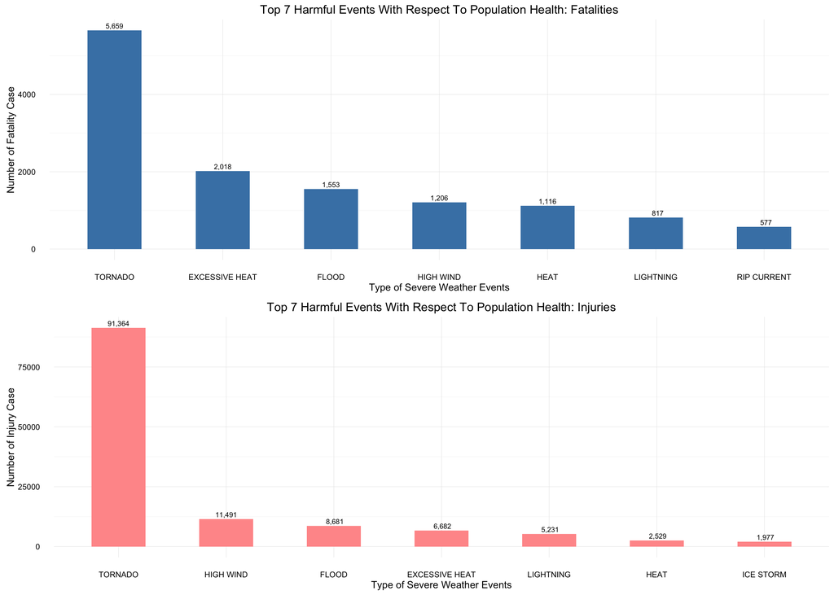

```r
F_P <- ggplot(data = Fatal[1:7,], aes(x = reorder(EVTYPE,-FATALITIES), y = FATALITIES)) +
        geom_bar(stat = "identity", fill = "steelblue",width = 0.5) +
        geom_text(aes(label = format(FATALITIES, big.mark = ",")), vjust = -0.4, color = "black", size = 3) +
        theme(aspect.ratio = .1) + labs(x = "Type of Severe Weather Events", y = "Number of Fatality Case") +
        ggtitle("Top 7 Harmful Events With Respect To Population Health: Fatalities") + theme_minimal()

I_P <- ggplot(data = Injure[1:7,], aes(x = reorder(EVTYPE,-INJURIES), y = INJURIES)) +
        geom_bar(stat = "identity", fill= "#FF9999", width = 0.5) +
        geom_text(aes(label = format(INJURIES, big.mark = ",")), vjust = -0.4, color = "black", size = 3) +
        theme(aspect.ratio = .1) + labs(x = "Type of Severe Weather Events", y = "Number of Injury Case") +
        ggtitle("Top 7 Harmful Events With Respect To Population Health: Injuries") + theme_minimal()

grid.arrange(F_P, I_P, nrow = 2)
```

##### Flood caused the greates economic damage from 1950 to Nov 2011.

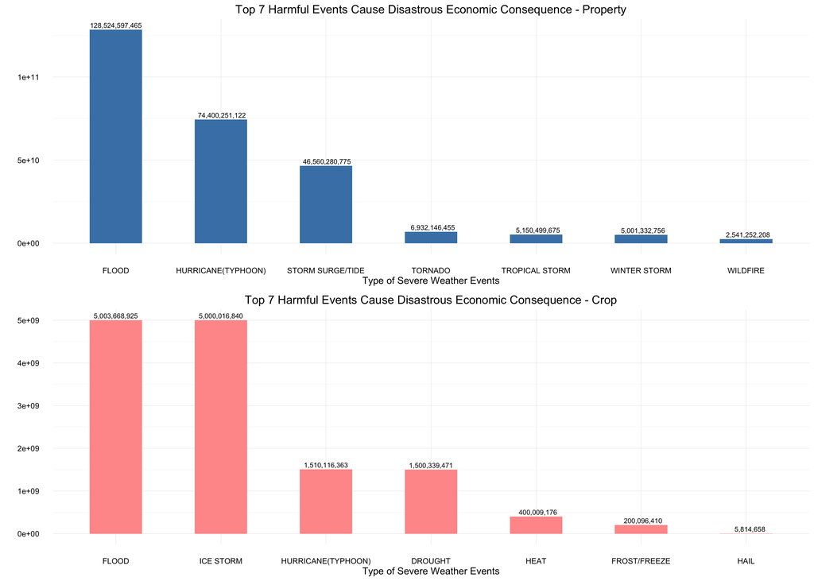

```r
P_P <- ggplot(data = Property_DMG[1:7,], aes(x = reorder(EVTYPE,-PROPDMG_NEW), y = PROPDMG_NEW)) +
        geom_bar(stat = "identity", fill = "steelblue",width = 0.5) +
        geom_text(aes(label = format(PROPDMG_NEW, big.mark = ",")), vjust = -0.4, color = "black", size = 3) +
        theme(aspect.ratio = .1) + labs(x = "Type of Severe Weather Events", y = "") +
        ggtitle("Top 7 Harmful Events Cause Disastrous Economic Consequence - Property") + theme_minimal()

C_P <- ggplot(data = Crop_DMG[1:7,], aes(x = reorder(EVTYPE,-CROPDMG_NEW), y = CROPDMG_NEW)) +
        geom_bar(stat = "identity", fill= "#FF9999", width = 0.5) +
        geom_text(aes(label = format(CROPDMG_NEW, big.mark = ",")), vjust = -0.4, color = "black", size = 3) +
        theme(aspect.ratio = .1) + labs(x = "Type of Severe Weather Events", y = "") +
        ggtitle("Top 7 Harmful Events Cause Disastrous Economic Consequence - Crop") + theme_minimal()
grid.arrange(P_P, C_P, nrow = 2)
```